# The Correlation of Bird Measurements & Their Diets

by the A-Team: Anna Scollay, Alice Bullard, Alice Miller, Annie O’Dell

2023-11-28

# Introduction

In this project we want to investigate the correlation between the diets and beak measurements of birds. We want to figure out if you can predict a bird diet based on their beak measurements alone.

### The Bird Beak

A bird’s beak anatomy can vary greatly in size and shape depending on its habitat and diet. A bird uses its for more than just eating, they are also used to build nests and sometimes to fight of other creatures invading their territory.

The bird beak is made up of the cere, nare, culmen, maxilla, mandible and gape fillange (see fig. 1).

Generally there are 4 types of bird beak:

- Granivorous: a cone shaped beak used for picking up and cracking seeds easily.
- Insectivorous: Broader and flatter beaks to create a larger surface area for bug catching in the air, or if they are more often feeding on the ground, more tweezer-like.
- Carnivorous: these are very strong beaks with the tip pointing downwards in order to hook onto meat easier.
- Pescatarian: long thing beaks with a spear-like tip for catching fish.

[figure not shown]

figure 1: Bird Beak Anatomy

### The Diets of Birds

The different diet of birds can be sorted into different trophic level. A trophic level defines the hierarchy of an organism in a ecosystem. The main three trophic levels we will be looking at are:

- Carnivore: A species whose diet consists of at least 70% of food resources from consuming live animals.
- Herbivore: A species whose diet consists of at least 70% of food resources from consuming plants.
- Omnivore: A species whose diet consists of a mixed consumption of plants and animals at an approximately equal rate.

Our data set also includes scavenger as a main trophic level but has very few birds fitting into this category compared to the other three. A scavenger bird gets its main food resources from dead animal carcasses.

These main trophic levels can be sub categorised into more niche trophics, like whether they eat mainly fruit(frugivore), insects & worms(invertivore), nectar(nectarivore) etc.

### Our Data

Our main data set for this project is birds_data. It contains different bird species measurements and behavior; such as their habitat, diet and migration patterns.

We will be focusing on the following variables of this data set that are useful in our project:

- Species ID: Unique identifier for species (or species group) linking to the Avibase dataset which provide detailed information on taxonomy, synonymy and distribution for the world’s birds.
- Total Individuals: Number of individual birds measured for each species.
- Complete Measures: Number of measured birds with a complete set of morphometric trait measurements.
- Beak Length: The nares length is measured from the front edge of the nostril to the tip of the beak (see fig 2). We’ve chosen to focus on nares length over culmen length (the length from the tip of the beak to the base of the skull) as beak width and depth also refer to the nostril location, whereas the culmen length refers to the skull.
- Beak Width: Width of the beak at the front edge of the nostrils (see fig 2).
- Beak Depth: Depth of the beak at the front edge of the nostrils (see fig 2).

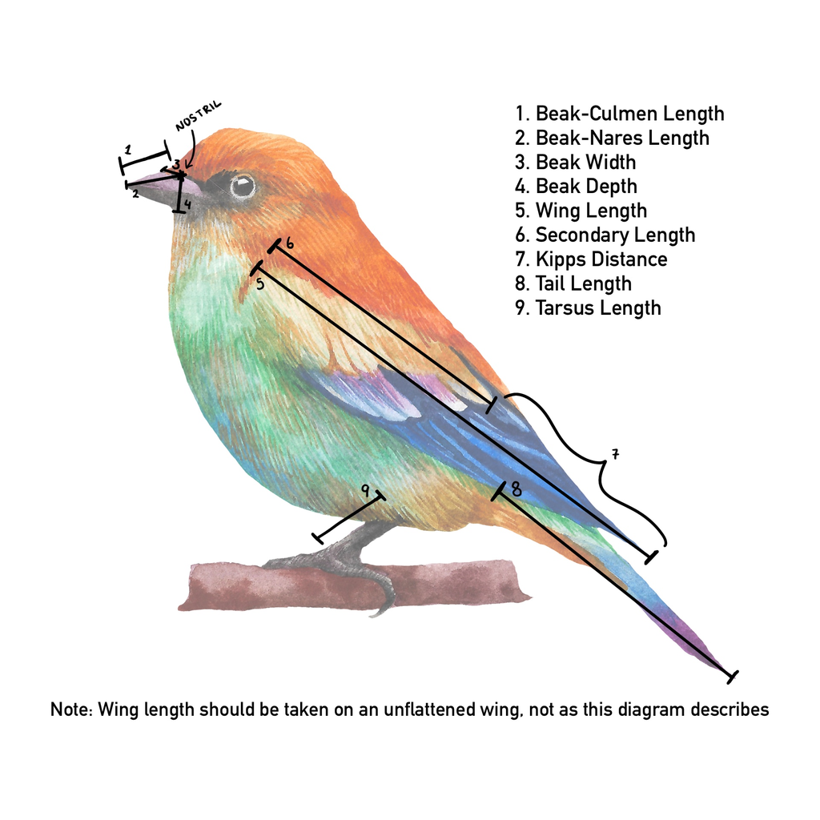

figure 2: Bird Measurements Taken

- bird beaks: https://burleydamgardencentre.co.uk/blog/what-are-the-different-types-of-bird-beaks/
- fig 1: https://kaylafisk.com/tag/drawing/